# Laboratory of Biostatistics Assessment

### Interpretation

The country that changed the most in mortality rate for the Female population, from 2011 to 2016, was Cyprus with an increase of 29.9%

```r
# For the male population

diff.Males %>%
  kable(align="ccccc") %>%
  kable_styling(bootstrap_options = c("striped", "hover")) %>%
  column_spec(1, bold = T)
```

| Year | Austria | Cyprus | European Union | Germany | Malta | Portugal |
| --- | --- | --- | --- | --- | --- | --- |
| 2012 | 9.8% | 30.2% | 3.1% | 2.1% | -18.2% | 0.1% |
| 2013 | 14.7% | 37.6% | 3.2% | -0.6% | -25.0% | 6.0% |
| 2014 | 11.8% | 30.5% | 6.0% | 3.7% | -9.5% | 14.3% |
| 2015 | 15.5% | 40.7% | 6.3% | 2.8% | -17.5% | 21.0% |
| 2016 | 7.8% | 19.8% | 8.4% | 4.5% | 71.5% | 25.7% |

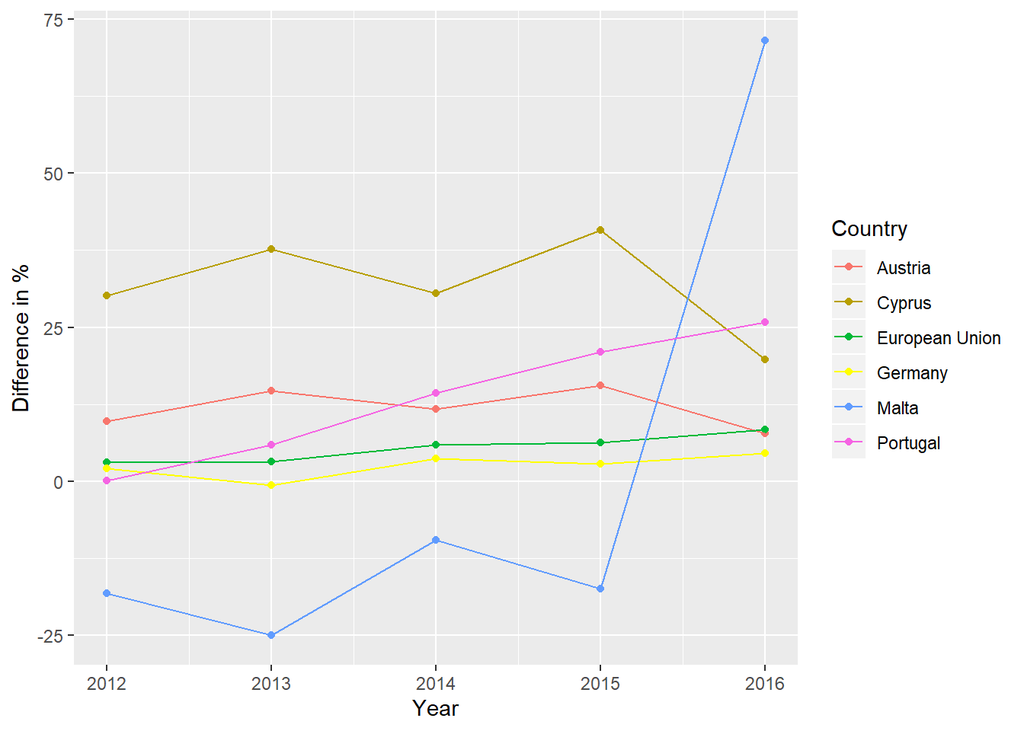

```r
# For the male population
data.diff.M %>%
  ggplot(aes(Year, per, group=Country, colour =Country))+
    geom_point()+
    geom_line()+
    ylab("Difference in %")+
    scale_colour_manual(labels = c("Austria", "Cyprus", "European Union", "Germany", "Malta", "Portugal"), values = c("#F8766D", "#B79F00", "#00BA38", "yellow", "#619CFF", "#F564E3"))
```

### Interpretation

The country that changed the most in mortality rate for the Male population, from 2011 to 2016, was Malta with an increase of 71.5%

## Fourth Question

> What are the five (5) most common causes of death by cancer in 2011? in 2016 for each of your countries?

```r
#Selecting cancer data for 2011
cancersF11 <- allCancer[Sex=="Females"][Year=="2011"][Age=="All"][order(CancerSite)]
cancersF11 <- cancersF11[, .(Deaths = sum(Deaths, na.rm = TRUE)), by = .(Country, CancerSite)]
fCancersEU11 <- cancersF11[Country=="European Union"]
fCancersEU11[order(-Deaths), head(.SD,5)]%>%
  kable(align = "cc")%>%
  kable_styling(bootstrap_options = "striped")
```

| Country | CancerSite | Deaths |
| --- | --- | --- |
| European Union | Breast | 91669 |
| European Union | Trachea, Bronchus and Lung | 79701 |
| European Union | Colon, Rectosigmoid Junction, Rectum, Anus and Anal Canal | 69409 |
| European Union | Pancreas | 38845 |
| European Union | Ovary | 29946 |

```r
fCancersPT11 <- cancersF11[Country=="Portugal"]
fCancersPT11[order(-Deaths), head(.SD,5)]%>%
  kable(align = "cc")%>%
  kable_styling(bootstrap_options = "striped")
```

| Country | CancerSite | Deaths |
| --- | --- | --- |
| Portugal | Colon, Rectosigmoid Junction, Rectum, Anus and Anal Canal | 1653 |
| Portugal | Breast | 1638 |
| Portugal | Stomach | 938 |
| Portugal | Trachea, Bronchus and Lung | 813 |
| Portugal | Pancreas | 601 |

```r
fCancersGE11 <- cancersF11[Country=="Germany"]
fCancersGE11[order(-Deaths), head(.SD,5)]%>%
  kable(align = "cc")%>%
  kable_styling(bootstrap_options = "striped")
```

| Country | CancerSite | Deaths |
| --- | --- | --- |
| Germany | Breast | 17830 |
| Germany | Trachea, Bronchus and Lung | 14293 |
| Germany | Colon, Rectosigmoid Junction, Rectum, Anus and Anal Canal | 12443 |
| Germany | Pancreas | 8131 |
| Germany | Ovary | 5841 |

```r
fCancersAU11 <- cancersF11[Country=="Austria"]
fCancersAU11[order(-Deaths), head(.SD,5)]%>%
  kable(align = "cc")%>%
  kable_styling(bootstrap_options = "striped")
```

| Country | CancerSite | Deaths |
| --- | --- | --- |
| Austria | Breast | 1490 |
| Austria | Trachea, Bronchus and Lung | 1304 |
| Austria | Colon, Rectosigmoid Junction, Rectum, Anus and Anal Canal | 1008 |
| Austria | Pancreas | 787 |
| Austria | Ovary | 488 |

```r
fCancersMA11 <- cancersF11[Country=="Malta"]
fCancersMA11[order(-Deaths), head(.SD,5)]%>%
  kable(align = "cc")%>%
  kable_styling(bootstrap_options = "striped")
```

| Country | CancerSite | Deaths |
| --- | --- | --- |
| Malta | Breast | 84 |
| Malta | Colon, Rectosigmoid Junction, Rectum, Anus and Anal Canal | 45 |
| Malta | Ovary | 37 |
| Malta | Pancreas | 32 |
| Malta | Trachea, Bronchus and Lung | 31 |

```r
fCancersCY11 <- cancersF11[Country=="Cyprus"]
fCancersCY11[order(-Deaths), head(.SD,5)]%>%
  kable(align = "cc")%>%
  kable_styling(bootstrap_options = "striped")
```

| Country | CancerSite | Deaths |
| --- | --- | --- |
| Cyprus | Breast | 111 |
| Cyprus | Trachea, Bronchus and Lung | 50 |
| Cyprus | Colon, Rectosigmoid Junction, Rectum, Anus and Anal Canal | 41 |
| Cyprus | Stomach | 27 |
| Cyprus | Ovary | 26 |

### Interpretation

```r
#Selecting cancer data for 2016
cancersF16 <- allCancer[Sex=="Females"][Year=="2016"][Age=="All"][order(CancerSite)]
cancersF16 <- cancersF16[, .(Deaths = sum(Deaths, na.rm = TRUE)), by = .(Country, CancerSite)]
fCancersEU16 <- cancersF16[Country=="European Union"]
fCancersEU16[order(-Deaths), head(.SD,5)]%>%
  kable(align = "cc")%>%
  kable_styling(bootstrap_options = "striped")
```

| Country | CancerSite | Deaths |
| --- | --- | --- |
| European Union | Breast | 95815 |
| European Union | Trachea, Bronchus and Lung | 90479 |
| European Union | Colon, Rectosigmoid Junction, Rectum, Anus and Anal Canal | 70078 |
| European Union | Pancreas | 43995 |
| European Union | Ovary | 29810 |

```r
fCancersPT16 <- cancersF16[Country=="Portugal"]
fCancersPT16[order(-Deaths), head(.SD,5)]%>%
  kable(align = "cc")%>%
  kable_styling(bootstrap_options = "striped")
```

| Country | CancerSite | Deaths |
| --- | --- | --- |
| Portugal | Breast | 1774 |
| Portugal | Colon, Rectosigmoid Junction, Rectum, Anus and Anal Canal | 1672 |
| Portugal | Trachea, Bronchus and Lung | 945 |
| Portugal | Stomach | 881 |
| Portugal | Pancreas | 678 |

```r
fCancersGE16 <- cancersF16[Country=="Germany"]
fCancersGE16[order(-Deaths), head(.SD,5)]%>%
  kable(align = "cc")%>%
  kable_styling(bootstrap_options = "striped")
```

| Country | CancerSite | Deaths |
| --- | --- | --- |
| Germany | Breast | 18603 |
| Germany | Trachea, Bronchus and Lung | 16499 |
| Germany | Colon, Rectosigmoid Junction, Rectum, Anus and Anal Canal | 11734 |
| Germany | Pancreas | 9070 |
| Germany | Ovary | 5496 |

```r
fCancersAU16 <- cancersF16[Country=="Austria"]
fCancersAU16[order(-Deaths), head(.SD,5)]%>%
  kable(align = "cc")%>%
  kable_styling(bootstrap_options = "striped")
```

| Country | CancerSite | Deaths |
| --- | --- | --- |
| Austria | Breast | 1605 |
| Austria | Trachea, Bronchus and Lung | 1553 |
| Austria | Colon, Rectosigmoid Junction, Rectum, Anus and Anal Canal | 916 |
| Austria | Pancreas | 895 |
| Austria | Ovary | 528 |

```r
fCancersMA16 <- cancersF16[Country=="Malta"]
fCancersMA16[order(-Deaths), head(.SD,5)]%>%
  kable(align = "cc")%>%
  kable_styling(bootstrap_options = "striped")
```

| Country | CancerSite | Deaths |
| --- | --- | --- |
| Malta | Breast | 73 |
| Malta | Colon, Rectosigmoid Junction, Rectum, Anus and Anal Canal | 60 |
| Malta | Trachea, Bronchus and Lung | 52 |
| Malta | Pancreas | 44 |
| Malta | Ovary | 30 |

```r
fCancersCY16 <- cancersF16[Country=="Cyprus"]
fCancersCY16[order(-Deaths), head(.SD,5)]%>%
  kable(align = "cc")%>%
  kable_styling(bootstrap_options = "striped")
```

| Country | CancerSite | Deaths |
| --- | --- | --- |
| Cyprus | Breast | 106 |
| Cyprus | Trachea, Bronchus and Lung | 62 |
| Cyprus | Colon, Rectosigmoid Junction, Rectum, Anus and Anal Canal | 42 |
| Cyprus | Pancreas | 35 |
| Cyprus | Ovary | 32 |

### Interpretation

The data for the most common causes of death by cancer for females in 2016 is much more homogenous than in 2011. The top three cancers are always Breast, Trachea/Bronchus/Lung and Colon cancers (Colon cancer is more deadly than the Respiratory Tract cancers only in Portugal and Malta). The fourth and fifth most common causes of death by cancer are Pancreas and Ovary for most countries, the only exception being Portugal where those positions are occupied by Stomach and Pancreas cancers, respectively.

```r
#Selecting cancer data for 2011
cancersM11 <- allCancer[Sex=="Males"][Year=="2011"][Age=="All"][order(CancerSite)]
cancersM11 <- cancersM11[, .(Deaths = sum(Deaths, na.rm = TRUE)), by = .(Country, CancerSite)]
mCancersEU <- cancersM11[Country=="European Union"]
mCancersEU[order(-Deaths), head(.SD,5)]%>%
  kable(align = "cc")%>%
  kable_styling(bootstrap_options = "striped")
```

| Country | CancerSite | Deaths |
| --- | --- | --- |
| European Union | Trachea, Bronchus and Lung | 186476 |
| European Union | Colon, Rectosigmoid Junction, Rectum, Anus and Anal Canal | 82554 |
| European Union | Prostate | 72901 |
| European Union | Pancreas | 39185 |
| European Union | Stomach | 36522 |

```r
mCancersPT <- cancersM11[Country=="Portugal"]
mCancersPT[order(-Deaths), head(.SD,5)]%>%
  kable(align = "cc")%>%
  kable_styling(bootstrap_options = "striped")
```

| Country | CancerSite | Deaths |
| --- | --- | --- |
| Portugal | Trachea, Bronchus and Lung | 2898 |
| Portugal | Colon, Rectosigmoid Junction, Rectum, Anus and Anal Canal | 2176 |
| Portugal | Prostate | 1821 |
| Portugal | Stomach | 1492 |
| Portugal | Liver and Intrahepatic Bile Ducts | 693 |

```r
mCancersGE <- cancersM11[Country=="Germany"]
mCancersGE[order(-Deaths), head(.SD,5)]%>%
  kable(align = "cc")%>%
  kable_styling(bootstrap_options = "striped")
```

| Country | CancerSite | Deaths |
| --- | --- | --- |
| Germany | Trachea, Bronchus and Lung | 29664 |
| Germany | Colon, Rectosigmoid Junction, Rectum, Anus and Anal Canal | 13868 |
| Germany | Prostate | 13328 |
| Germany | Pancreas | 7815 |
| Germany | Stomach | 5694 |

```r
mCancersAU <- cancersM11[Country=="Austria"]
mCancersAU[order(-Deaths), head(.SD,5)]%>%
  kable(align = "cc")%>%
  kable_styling(bootstrap_options = "striped")
```

| Country | CancerSite | Deaths |
| --- | --- | --- |
| Austria | Trachea, Bronchus and Lung | 2332 |
| Austria | Colon, Rectosigmoid Junction, Rectum, Anus and Anal Canal | 1172 |
| Austria | Prostate | 1152 |
| Austria | Pancreas | 759 |
| Austria | Liver and Intrahepatic Bile Ducts | 534 |

```r
mCancersMA <- cancersM11[Country=="Malta"]
mCancersMA[order(-Deaths), head(.SD,5)]%>%
  kable(align = "cc")%>%
  kable_styling(bootstrap_options = "striped")
```

| Country | CancerSite | Deaths |
| --- | --- | --- |
| Malta | Trachea, Bronchus and Lung | 127 |
| Malta | Colon, Rectosigmoid Junction, Rectum, Anus and Anal Canal | 65 |
| Malta | Prostate | 35 |
| Malta | Stomach | 33 |
| Malta | Pancreas | 32 |

```r
mCancersCY <- cancersM11[Country=="Cyprus"]
mCancersCY[order(-Deaths), head(.SD,5)]%>%
  kable(align = "cc")%>%
  kable_styling(bootstrap_options = "striped")
```

| Country | CancerSite | Deaths |
| --- | --- | --- |
| Cyprus | Trachea, Bronchus and Lung | 186 |
| Cyprus | Prostate | 81 |
| Cyprus | Colon, Rectosigmoid Junction, Rectum, Anus and Anal Canal | 50 |
| Cyprus | Bladder | 36 |
| Cyprus | Pancreas | 31 |

### Interpretation

For 2011, the most common causes of death by cancer, for males, are generally the same between countries, with Trachea/Bronchus/Lung cancer being the most common for all countries, followed by Colon and Prostate (except Cyprus where Prostate cancer caused more deaths than Colon). The last two positions of the table are occupied by Stomach, Pancreas, Liver or Bladder cancers.

```r
#Selecting cancer data for 2016
cancersM16 <- allCancer[Sex=="Males"][Year=="2016"][Age=="All"][order(CancerSite)]
cancersM16 <- cancersM16[, .(Deaths = sum(Deaths, na.rm = TRUE)), by = .(Country, CancerSite)]
mCancersEU <- cancersM16[Country=="European Union"]
mCancersEU[order(-Deaths), head(.SD,5)]%>%
  kable(align = "cc")%>%
  kable_styling(bootstrap_options = "striped")
```

| Country | CancerSite | Deaths |
| --- | --- | --- |
| European Union | Trachea, Bronchus and Lung | 184528 |
| European Union | Colon, Rectosigmoid Junction, Rectum, Anus and Anal Canal | 86476 |
| European Union | Prostate | 76971 |
| European Union | Pancreas | 44060 |
| European Union | Liver and Intrahepatic Bile Ducts | 35764 |

```r
mCancersPT <- cancersM16[Country=="Portugal"]
mCancersPT[order(-Deaths), head(.SD,5)]%>%
  kable(align = "cc")%>%
  kable_styling(bootstrap_options = "striped")
```

| Country | CancerSite | Deaths |
| --- | --- | --- |
| Portugal | Trachea, Bronchus and Lung | 3140 |
| Portugal | Colon, Rectosigmoid Junction, Rectum, Anus and Anal Canal | 2237 |
| Portugal | Prostate | 1837 |
| Portugal | Stomach | 1316 |
| Portugal | Pancreas | 860 |

```r
mCancersGE <- cancersM16[Country=="Germany"]
mCancersGE[order(-Deaths), head(.SD,5)]%>%
  kable(align = "cc")%>%
  kable_styling(bootstrap_options = "striped")
```

| Country | CancerSite | Deaths |
| --- | --- | --- |
| Germany | Trachea, Bronchus and Lung | 29371 |
| Germany | Prostate | 14434 |
| Germany | Colon, Rectosigmoid Junction, Rectum, Anus and Anal Canal | 13652 |
| Germany | Pancreas | 9031 |
| Germany | Liver and Intrahepatic Bile Ducts | 5429 |

```r
mCancersAU <- cancersM16[Country=="Austria"]
mCancersAU[order(-Deaths), head(.SD,5)]%>%
  kable(align = "cc")%>%
  kable_styling(bootstrap_options = "striped")
```

| Country | CancerSite | Deaths |
| --- | --- | --- |
| Austria | Trachea, Bronchus and Lung | 2443 |
| Austria | Prostate | 1242 |
| Austria | Colon, Rectosigmoid Junction, Rectum, Anus and Anal Canal | 1229 |
| Austria | Pancreas | 795 |
| Austria | Liver and Intrahepatic Bile Ducts | 603 |

```r
mCancersMA <- cancersM16[Country=="Malta"]
mCancersMA[order(-Deaths), head(.SD,5)]%>%
  kable(align = "cc")%>%
  kable_styling(bootstrap_options = "striped")
```

| Country | CancerSite | Deaths |
| --- | --- | --- |
| Malta | Trachea, Bronchus and Lung | 131 |
| Malta | Colon, Rectosigmoid Junction, Rectum, Anus and Anal Canal | 60 |
| Malta | Prostate | 49 |
| Malta | Pancreas | 42 |
| Malta | Liver and Intrahepatic Bile Ducts | 32 |

```r
mCancersCY <- cancersM16[Country=="Cyprus"]
mCancersCY[order(-Deaths), head(.SD,5)]%>%
  kable(align = "cc")%>%
  kable_styling(bootstrap_options = "striped")
```

| Country | CancerSite | Deaths |
| --- | --- | --- |
| Cyprus | Trachea, Bronchus and Lung | 197 |
| Cyprus | Prostate | 90 |
| Cyprus | Colon, Rectosigmoid Junction, Rectum, Anus and Anal Canal | 74 |
| Cyprus | Pancreas | 46 |
| Cyprus | Bladder | 44 |

### Interpretation

# Conclusions:

- This data shows an **overall slight increase in the mortality rate for Liver and Intrahepatic Bile Ducts cancer** (from 2011 to 2016)
- **Lack of data for 2017** makes this analysis more difficult
- The data also shows that this cancer is more aggressive to older people, showing **higher mortality rates for higher age groups**.
- **Most common cancers are** (almost) **the same** from 2011 to 2016. There is a slight overall trend for the number of deaths to increase
- Given the data limitations, the **true mortality rate may be higher**